# Lecture2_Code

Alex Hoagland

2022-08-11

```r
################################################################################
# I like to include several additional notes in the header of my files here:
#
# Last modified: 8/11/2022
#
### PURPOSE:
  # Lecture 2 code and output file
#
### NOTES:
  # - uses the Tidyverse package and Dplyr
################################################################################


### 0. Load the packages we will need for this file ####
library(tidyverse) # load the installed package for each new session of R
library(broom)

set.seed(122333) # Setting the seed helps to make random number generators give us the same numbers across machines
################################################################################
```

## Probability Review

### Assigning Probabilities

Let’s keep the example of **health state** as a random variable, and assign some (made-up) proabilities:

```r
##### Probability Review #####
p_healthy <- 0.75 # Assign 3 main probabilities
p_acute <- 0.2
p_chronic <- 0.05
```

We also need to have some joint probabilities that tell us if there is any overlap between states. These help us calculate **conditional probabilities**, or how information about part of my state informs me about the rest of my health state.

```r
p_acute_chronic <- 0.02 # Assign joint probabilities
p_healthy_acute <- 0
p_healthy_chronic <- 0
p_healthy_acute_chronic <- 0

# Conditional probabilities
p_chronic_givenacute <- p_acute_chronic / p_acute
```

### Conditional Probabilities and Independence

We can then test if the information is *independent* – does knowing I have an acute condition inform me of the probability of a chronic one?

```r
p_chronic_givenacute == p_chronic * p_acute
```

```
## [1] FALSE
```

### Total Probabilty

How does my probability of having a chronic illness evolve over time? Let’s first consider just two periods.

```r
# Total probability
day1 <- p_chronic # On first day, probability of illness is the known probability
day2 <- p_chronic * (1-p_chronic) # The probability of being healthy on day1, then developing an illness on the second day

totalprob <- day1+day2 # Total probability is sum over time
```

Now suppose we want to know – how long would I have to survive until my total probability was higher than 0.15? For this, we’ll need a function.

```r
dayprob <- function(n) {
    # This function returns the probability of (i) being healthy until day n, then (ii) getting a chronic condition on day n
  return(p_chronic * (1-p_chronic)^n)
}

# Now let's apply the function
mydata <- tibble( x=seq(1,10,by=1) ) %>%  # Periods 1 through 10
  mutate(dayprob=dayprob(x)) %>% # Daily probability
  mutate(totalprob = cumsum(dayprob)) # Total probability = sum of dailies

# What's the first day after which total prob is > 0.15?
answer <- mydata %>%
  mutate(tokeep = totalprob>0.15) %>%
  filter(tokeep==1) %>%
  mutate(first = min(x)) %>%
  filter(row_number()==1) %>%
  pull(first)

print(paste0("The number of days before totalprob > 0.15 is ", answer ,sep=""))
```

```
## [1] "The number of days before totalprob > 0.15 is 4"
```

### Bayes’ Rule

Let’s look at how learning information about my health state should lead you to update yours. we’ll define this as a function again that just implements Bayes’ rule:

$$P(A|B) =
\frac{P(B|A)P(A)}{P(B)}$$

```r
# Update function for p_chronic
update_chronic <- function(oldprob) {
  p_x1_you_given_x3_me <- .7
    # Experiment with changing this probability to see how the graph below changes
    # What happens if this is .75? .1? What does changing this mean in terms of the example?

  p_x1_you_given_x1_me <- .75
  num <- p_x1_you_given_x3_me * oldprob
  den <- p_x1_you_given_x3_me * oldprob + p_x1_you_given_x1_me * (1-oldprob)
  return(num/den) # Why write it this way? Just so each term is easily digestable.
    # Think of your code reader, not just the output!
}
```

Once the function is defined, we run a simple simulation: how do our beliefs update for each day that our other family members do **not** come down with an illness?

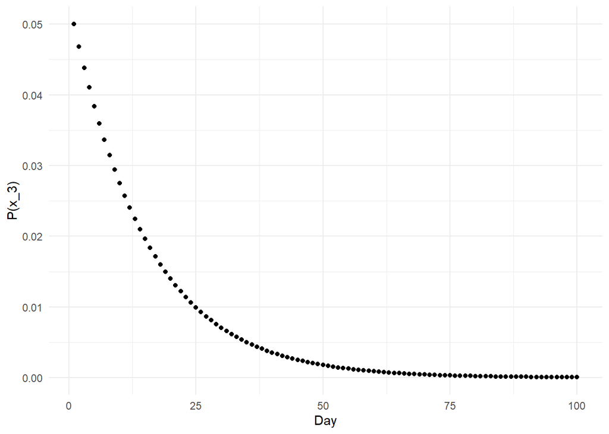

```r
mydata <- rep(NA, 100) # Set blanks for 100 days
mydata[1] <- .05 # Set first probability at .05
for (i in 2:100) {
  mydata[i] <- update_chronic(mydata[i-1])
}

# Now plot
mydata <- tibble(mydata) %>% mutate(x=row_number())
ggplot(mydata,aes(x,mydata)) + geom_point() + theme_minimal() + labs(x = "Day", y = "P(x_3)")
```

## Regression

### Preliminaries

Let’s first set up our data in the case where we **know** our data generating process (DGP). Pretend that we know that

$$y = 5.5x+u$$

for some random variation $u$.

```r
tb <- tibble(
  x = rnorm(10000),
  u = rnorm(10000),
  y = 5.5*x + 12*u
) # Here's our true model, with some randomness baked in
```

In this case, what happens when we run a regression of $y$ on $x$?

```r
tb %>% lm(y ~ x, .)
```

```
##
## Call:
## lm(formula = y ~ x, data = .)
##
## Coefficients:
## (Intercept)            x
##     0.02148      5.36837
```

### Visualizing Regressions

There’s **a lot** we can do in R with regressions. Let’s try some!

```r
# Looking at your model output
reg_tb <- lm(y ~ x, data=tb) # Store regression as an object

summary(reg_tb) # gives you a full summary
```

```
##
## Call:
## lm(formula = y ~ x, data = tb)
##
## Residuals:
##     Min      1Q  Median      3Q     Max
## -50.573  -8.021  -0.102   8.187  45.095
##
## Coefficients:
##             Estimate Std. Error t value Pr(>|t|)
## (Intercept)  0.02148    0.12000   0.179    0.858
## x            5.36837    0.11933  44.988   <2e-16 ***
## ---
## Signif. codes:  0 '***' 0.001 '**' 0.01 '*' 0.05 '.' 0.1 ' ' 1
##
## Residual standard error: 12 on 9998 degrees of freedom
## Multiple R-squared:  0.1683, Adjusted R-squared:  0.1683
## F-statistic:  2024 on 1 and 9998 DF,  p-value: < 2.2e-16
```

```r
regdata <- tidy(reg_tb, conf.int=TRUE) # Stores regression output in a data frame
regouts <- glance(reg_tb) # Stores other regression features in a data frame
```

Rather than just seeing what the regression returns (e.g., in a table), we can also look at its performance in the data (e.g., with more data visualizations)

```r
tb <- tb %>%
  mutate(
    yhat1 = predict(lm(y ~ x, .)),
    yhat2 = 0.0732608 + 5.685033*x,
    uhat1 = residuals(lm(y ~ x, .)),
    uhat2 = y - yhat2
  ) # How close are our predictions?

summary(tb[-1:-3])
```

```
##      yhat1               yhat2               uhat1              uhat2
##  Min.   :-22.65252   Min.   :-23.93820   Min.   :-50.5726   Min.   :-50.42211
##  1st Qu.: -3.65746   1st Qu.: -3.82269   1st Qu.: -8.0206   1st Qu.: -8.07389
##  Median :  0.01331   Median :  0.06461   Median : -0.1019   Median : -0.15588
##  Mean   :  0.01152   Mean   :  0.06271   Mean   :  0.0000   Mean   : -0.05119
##  3rd Qu.:  3.64442   3rd Qu.:  3.90990   3rd Qu.:  8.1873   3rd Qu.:  8.10365
##  Max.   : 19.59058   Max.   : 20.79668   Max.   : 45.0946   Max.   : 45.09122
```

The most common visualization, especially for a one-dimensional regression, is just to plot the line against the data. Look closely at this command and let’s walk through the syntax as we develop the plot.

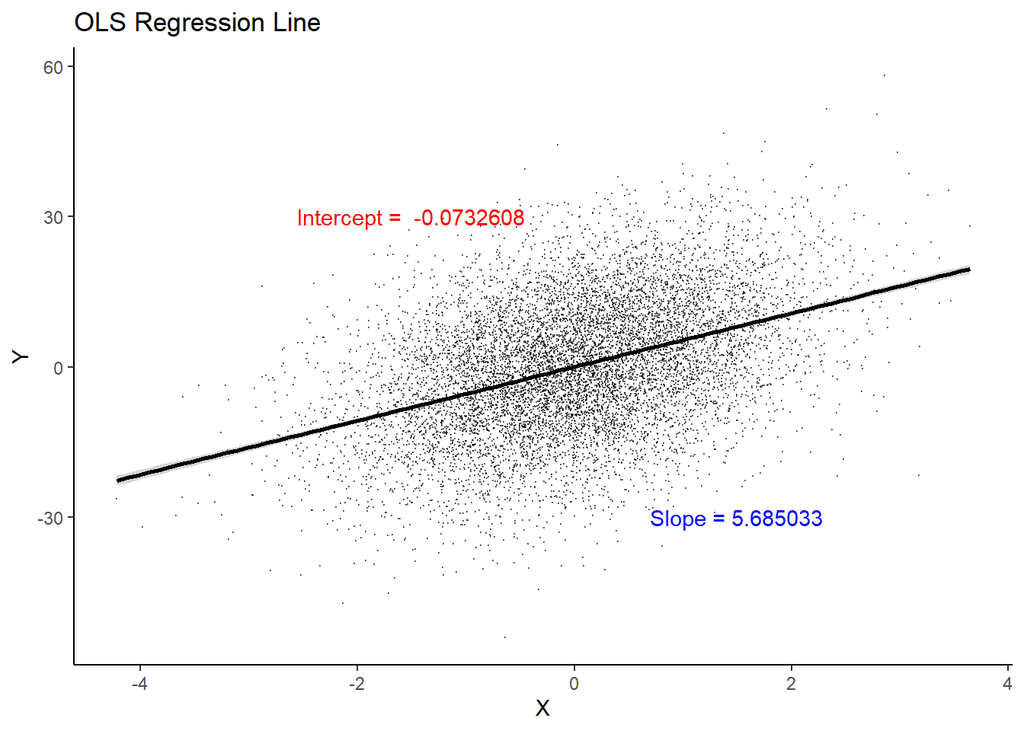

```r
tb %>%
  lm(y ~ x, .) %>%
  ggplot(aes(x=x, y=y)) +
  ggtitle("OLS Regression Line") +
  geom_point(size = 0.05, color = "black", alpha = 0.5) +
  geom_smooth(method = lm, color = "black") +
  annotate("text", x = -1.5, y = 30, color = "red",
           label = paste("Intercept = ", -0.0732608)) +
  annotate("text", x = 1.5, y = -30, color = "blue",
           label = paste("Slope =", 5.685033)) +
  theme_classic() + labs(x="X", y="Y")
```

### Measures of Regression performance

Let’s calculate the R-squared by hand first:

```r
SST <- tb %>% mutate(ybar=mean(y), sst=(y-ybar)^2) %>% select(sst) %>% summarise(sum(sst))
SSE <- tb %>% mutate(ybar=mean(y), sse=(yhat1-ybar)^2) %>% select(sse) %>% summarise(sum(sse))
SSR <- tb %>% mutate(ssr=uhat1^2) %>% select(ssr) %>% summarise(sum(ssr))

R2 <- SSE/SST
```

You can also retrieve it straight from the lm command (this is almost always true for whatever regression object you might want!)

```r
summary(reg_tb) # Full summary
```

```
##
## Call:
## lm(formula = y ~ x, data = tb)
##
## Residuals:
##     Min      1Q  Median      3Q     Max
## -50.573  -8.021  -0.102   8.187  45.095
##
## Coefficients:
##             Estimate Std. Error t value Pr(>|t|)
## (Intercept)  0.02148    0.12000   0.179    0.858
## x            5.36837    0.11933  44.988   <2e-16 ***
## ---
## Signif. codes:  0 '***' 0.001 '**' 0.01 '*' 0.05 '.' 0.1 ' ' 1
##
## Residual standard error: 12 on 9998 degrees of freedom
## Multiple R-squared:  0.1683, Adjusted R-squared:  0.1683
## F-statistic:  2024 on 1 and 9998 DF,  p-value: < 2.2e-16
```

```r
summary(reg_tb)$r.squared # Specifically, the r-squared
```

```
## [1] 0.1683498
```

### Unbiasednses of our regressions

We’ve already shown that our model does reasonably well matching the truth, but can we show that in general? Let’s try another simulation.

Let’s use this DGP to create a random sample of data ($N$=10,000) and run a regression. We will repeat this procedure 1,000 times, storing the regression coefficients each time.

```r
lm <- lapply( # lapply is a useful command (see ?lapply to access documentation)
  1:1000,
  function(x) tibble(
    x = 9*rnorm(10000), # Distribution for x (rnorm(N) creates N random draws from a N(0,1) distribution)
    u = 36*rnorm(10000), # Distribution for e
    y = 3 + 2*x + u
  ) %>%
    lm(y ~ x, .)
) # This runs 1,000 regressions with new data every time
# lapply is useful here since we want to resample data *and* do a regression at the same time.
```

What are the results of this simulation? Let’s make a table and a graph.

```r
as_tibble(t(sapply(lm, coef))) %>%
  summary(x) # Summarize the regression coefficients (tabular)
```

```
##   (Intercept)          x
##  Min.   :1.538   Min.   :1.838
##  1st Qu.:2.755   1st Qu.:1.972
##  Median :2.999   Median :1.998
##  Mean   :2.995   Mean   :1.998
##  3rd Qu.:3.243   3rd Qu.:2.025
##  Max.   :4.192   Max.   :2.145
```

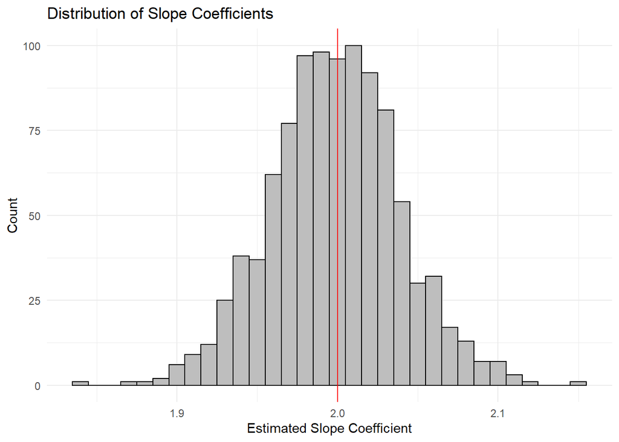

```r
as_tibble(t(sapply(lm, coef))) %>%
  ggplot()+
  geom_histogram(aes(x), binwidth = 0.01,fill="gray",color='black') +
  theme_minimal() +
  labs(x="Estimated Slope Coefficient", y="Count",title="Distribution of Slope Coefficients") +
  geom_vline(xintercept=2,color='red')
```